# Becoming the Very Best API: Contacting the pokeAPI

Supro Debnath 2022-06-18

- Requirements
- pokeAPI Functions
  - `Generation Pokedex`
  - `TypeDex`
  - `pokeAPI Wrapper Function`
- Visuals
  - `The Original 151: Kanto Region`
  - `The Childhood Favorite: Hoenn Region`
  - `The People's Champ: Sinnoh Region`
- Conclusion/Future Expectations

This vignette is a step-by-step guide to interacting with the [pokeAPI](https://pokeapi.co/docs/v2). There are a few functions in here that explore the data present, as well as some visualizations that highlight interesting patterns in the world of pokemon. The ids are represented as numeric (i.e. `Generation 1` referring to the Kanto pokemon, or `Type 3` referring to the `Flying` type). For that reason, if you intend on using any of these functions, please be mindful of how the function inputs correspond to the data you are trying to pull.

## Requirements

To interact with this API, a few packages must be installed.

- `jsonlite`: Works with JSON in R and is useful for parsing data and interacting with a web API.
- `httr`: Provides useful tools for working with HTTP.
- `tidyverse`: Collection of R packages that contribute heavily to API interaction and data visualization.
- `knitr`: Provides tools for dynamic reporting in R.
- `dplyr`: Package that provides tools for working with data frames.
- `ggplot2`: Powerful for complex data visualizations.

```r
library(jsonlite)
library(httr)
library(tidyverse)
library(knitr)
library(dplyr)
library(ggplot2)
library(ggpubr)
```

## pokeAPI Functions

This section is dedicated to the two functions I’ve created to pull data from this API. This API had a lot of information I found irrelevant for my analysis, as I want to hone in on which pokemon are the best and which type is the most prevalent.

### `Generation Pokedex`

This function returns a complete pokedex from the `generation` endpoint. It returns a `data.frame` of pokemon found in that generation, listing their `name`, `id`, `typing` (i.e. fighting type or bug/flying type), `ability` (returning the primary ability, not all pokemon have hidden abilities), and their `stats` (attack, speed, etc.). This function takes a numeric input from `1` to `8`, which is the order of each generation being introduced.

```r
gendex <- function(gen) {

  #Create a conditional input statement for this function. If an invalid input is put in, the function breaks.
  if ((gen > 8) || (gen < 1)) {
    stop("This is a non-existent generation. Please refine search or submit a numeric input from 1 to 8.")
  }

  #Parse through the data from the given URL.
  respGEN <- GET(paste0("http://pokeapi.co/api/v2/generation/", gen))
  conGEN <- content(respGEN, "parsed")

  #Create an empty data frame of the moves URL that will provide stats on different moves.
  df_pokeGEN <- do.call(rbind.data.frame, c(conGEN$pokemon_species, stringsAsFactors = FALSE))

  #Create a function that will parse through the URLs in the move page.
  pokePULL <- function(url) {
    specCON <- content(GET(url), "parsed")

  #Call in the variable capture_rate from the pokemon_species URL.
    catch_rate <- specCON$capture_rate

  #Parse through the varieties URL and get relevant information.
    pokeURL <- specCON$varieties[[1]]$pokemon$url
    pokeCON <- content(GET(pokeURL), "parsed")

  #Filter through all relevant statistics for each pokemon and label them accordingly.
    stats <- sapply(pokeCON$stats, function(stats) stats[["base_stat"]])
    names(stats) <- sapply(pokeCON$stats, function(stats) stats[["stat"]][["name"]])

  #Create a base loop for going through typing. There are 2 slots, indicating a combo type or single type.
    for (i in seq_along(pokeCON$types)) {
      if (pokeCON$types[[i]][["slot"]] == 1){
        type <- pokeCON$types[[1]][["type"]][["name"]]
      }
      else {
        type <- paste0(pokeCON$types[[1]][["type"]][["name"]], "/",
                       pokeCON$types[[2]][["type"]][["name"]])
      }
    }

  #Same loop structure for abilities, although we are only going to look at main abilities. To analyze hidden or secondary abilities, add more options.
    for (i in seq_along(pokeCON$abilities)) {
      if (pokeCON$abilities[[i]][["slot"]] == 1) {
        ability <- pokeCON$abilities[[1]][["ability"]][["name"]]
      }
    }

  #Return necessary Pokemon information.
    return(
      c(
        name = pokeCON$name,
        pokedex_id = pokeCON$id,
        type = type,
        ability = ability,
        weight = pokeCON$weight,
        as.list(stats),
        catch_rate = round((catch_rate/255)*100)
      )
    )
  }

  #Clean up data frame and organize data by Pokemon ID.
  pokeLIST <- lapply(df_pokeGEN$url, pokePULL)
  pokedex <- do.call(rbind.data.frame, c(pokeLIST, stringsAsFactors = FALSE))
  pokedex <- pokedex %>% arrange(pokedex_id)
  colnames(pokedex)[12] <- "catch_rate_pct"
  return(pokedex)
}
```

### `TypeDex`

This function returns a complete list of moves from the `type` endpoint. It returns a `data.frame` of moves found in that type, listing their `name`, `id`, `accuracy`, `power`, `pp` (how many times the move can be used), `crit` (whether it can critically strike), `drain` (whether the move drains health from the opponent), and `flinch` (the chance the move causes the enemy to flinch. This function takes a numeric input from `1` to `20`, which is the number of types present.

```r
typedex <- function(type) {

  #Create a conditional input statement for this function. If an invalid input is put in, the function breaks.
  if ((type > 20) || (type < 1)) {
    stop("This is a non-existent typing. Please refine search or submit a numeric input from 1 to 20.")
  }

  #Parse through the data from the given URL.
  respTYPE <- GET(paste0("http://pokeapi.co/api/v2/type/", type))
  conTYPE <- content(respTYPE, "parsed")

  #Create an empty data frame of the moves URL that will provide stats on different moves.
  df_typeGEN <- do.call(rbind.data.frame, c(conTYPE$moves, stringsAsFactors = FALSE))

  #Create a function that will parse through the URLs in the move page.
  typePULL <- function(url) {
    moveCON <- content(GET(url), "parsed")

    #IF statements that filter out values listed as null for specific categories.
    if (is.null(moveCON$accuracy)) {
        moveCON$accuracy = "NA"
    }

    if (is.null(moveCON$power)) {
        moveCON$power = "NA"
    }

    #Return necessary stats.
    return(
      c(
        name = moveCON$name,
        move_id = moveCON$id,
        accuracy = moveCON$accuracy,
        power = moveCON$power,
        pp = moveCON$pp,
        crit = moveCON$meta$crit_rate,
        drain = moveCON$meta$drain,
        flinch = moveCON$meta$flinch_chance
      )
    )
  }

  #Clean up data frame and insert new names for relevant columns.
  typeLIST <- lapply(df_typeGEN$url, typePULL)
  typedex <- do.call(rbind.data.frame, c(typeLIST, stringsAsFactors = FALSE))
  names(typedex) <- c('name', 'move_id', 'accuracy', 'power', 'pp', 'crit_rate', 'drain', 'flinch_chance')
  typedex <- type.convert(typedex)
  return(typedex)
}
```

### `pokeAPI Wrapper Function`

Wrapper function for all the functions created.

```r
pokeAPI <- function(func, ...){
  ###
  # This function is a wrapper for the other functions. It takes in the name
  # of the function to use as a character and any additional arguments for that
  # function.
  ###

  # Find and call the appropriate function using conditional logic.

  if (func == "gen"){
    output <- gendex(...)
  }
  else if (func == "type"){
    output <- typedex(...)
  }
  else {
    stop("ERROR: Argument for func is not valid!")
  }

  # Return the output from the appropriate function.
  return(output)
}
```

## Visuals

### `The Original 151: Kanto Region`

To start the data exploration, I wanted to look at the generation where the phrase “Gotta Catch Em All” came from. What pokemon/pokemon types are the best in the game? Is there really a reason to picking Charizard over Blastoise, and is Venusaur really that useless? To start, we will load in the Pokedex information with our `pokeAPI` wrapper function, then add in a new variable called `totalstats` that is the aggregate of all six pokemon stats.

```r
kanto <- pokeAPI("gen", 1)
kanto <- kanto %>% mutate(totalstats = hp+attack+defense+special.attack+special.defense+speed)
head(kanto)
```

```
##         name pokedex_id         type  ability weight hp attack defense special.attack special.defense
## 1  bulbasaur          1 grass/poison overgrow     69 45     49      49             65              65
## 2    ivysaur          2 grass/poison overgrow    130 60     62      63             80              80
## 3   venusaur          3 grass/poison overgrow   1000 80     82      83            100             100
## 4 charmander          4         fire    blaze     85 39     52      43             60              50
## 5 charmeleon          5         fire    blaze    190 58     64      58             80              65
## 6  charizard          6  fire/flying    blaze    905 78     84      78            109              85
##   speed catch_rate_pct totalstats
## 1    45             18        318
## 2    60             18        405
## 3    80             18        525
## 4    65             18        309
## 5    80             18        405
## 6   100             18        534
```

With our data loaded, I now want to look at the top 25 strongest pokemon from this generation by total stats. While I anticipate most of the legendary pokemon being included in this list, I do want to see what types are the most prevalent (or combination of types).

[figure not shown]

```r
kanto_strongest <- top_n(kanto, n=25, totalstats)

plot1 <- ggplot(kanto_strongest, aes(x=name, y=totalstats, fill=type)) + geom_bar(stat='identity') + coord_flip() + ggtitle("Strongest Kanto Pokemon") + xlab("Pokemon Name") + ylab("Total Stats")  + theme(plot.title = element_text(hjust = 0.5))
plot1
```

Let’s dive into the chances of catching these pokemon in the wild (not taking into account pokeball type).

[figure not shown]

```r
plot2 <- ggplot(kanto_strongest, aes(x=name, y=catch_rate_pct, fill=type)) + geom_bar(stat='identity') + coord_flip() + ggtitle("Strongest Kanto Pokemon Catch Rate") + xlab("Pokemon Name") + ylab("Catch Rate %")  + theme(plot.title = element_text(hjust = 0.5))
plot2
```

All three starters are present, though Charizard has a slight edge. After looking at the typing and the Pokemon included, I wanted to see the spread of total stats, seeing whether the most common Pokemon total stat number was.

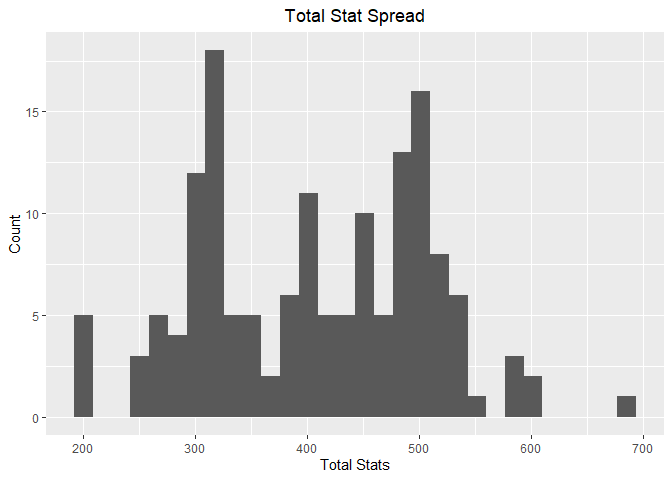

```r
plot3 <- ggplot(kanto, aes(x=totalstats)) + geom_histogram() + ggtitle("Total Stat Spread") + xlab("Total Stats") + ylab("Count") + theme(plot.title = element_text(hjust = 0.5))
plot3
```

Let’s grab a numerical summary of this `totalstats` breakdown by type.

```r
kanto %>% group_by(type) %>% summarise(avg = round(mean(totalstats)), med = median(totalstats), var = round(var(totalstats)))
```

```
## # A tibble: 38 × 4
##    type              avg   med   var
##    <chr>           <dbl> <dbl> <dbl>
##  1 bug               300  205  30025
##  2 bug/flying        448  448.  5512
##  3 bug/grass         345  345   7200
##  4 bug/poison        310  305  12775
##  5 dragon            360  360   7200
##  6 dragon/flying     600  600     NA
##  7 electric          440  488.  8150
##  8 electric/flying   580  580     NA
##  9 electric/steel    395  395   9800
## 10 fairy             403  403  12800
## # … with 28 more rows
```

```r
summary(kanto$totalstats)
```

```
##    Min. 1st Qu.  Median    Mean 3rd Qu.    Max.
##   195.0   320.0   405.0   407.6   490.0   680.0
```

There are some types with “NA” since there is only one pokemon of that type.

Next, we want to look at the typing breakdown and the count of each in the entire set of 151 pokemon.

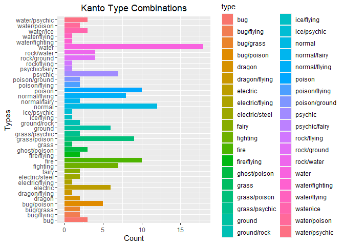

```r
plot4 <- ggplot(kanto, aes(x=type, fill=type))  + geom_bar() + coord_flip() + ggtitle("Kanto Type Combinations") + xlab("Types") + ylab("Count") + theme(plot.title = element_text(hjust = 0.5))
plot4
```

There are an absurd number of water-type pokemon, with a few other types having high counts compared to the rest. I want to see the spread of `totalstats` by type and see which types are better overall for stats.

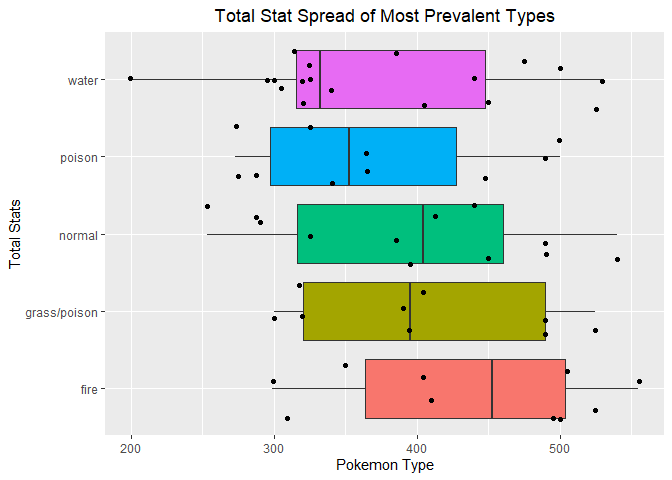

```r
kanto_spread <- filter(kanto, type == 'water' | type == 'normal' | type == 'poison' | type == 'fire' | type == 'grass/poison')

plot5 <- ggplot(kanto_spread, aes(x=type, y=totalstats, fill=type)) + geom_boxplot(show.legend = FALSE) + geom_jitter(shape=16) + coord_flip() + theme(legend.position = "none", plot.title = element_text(hjust = 0.5)) + ggtitle("Total Stat Spread of Most Prevalent Types") + xlab("Total Stats") + ylab("Pokemon Type")
plot5
```

It looks like on average, fire type pokemon are overall stronger and will have higher overall stats than the rest of the types. Now, lets look at a table of all the fire type moves that are available for these pokemon to learn.

```r
k_moves <- pokeAPI("type", 10)
table1 <- table(k_moves$power, k_moves$pp)
knitr::kable(table1, caption = "Power of Fire Moves by PP")
```

|  | 1 | 5 | 10 | 15 | 20 | 25 |
| --- | --- | --- | --- | --- | --- | --- |
| 35 | 0 | 0 | 0 | 1 | 0 | 0 |
| 40 | 0 | 0 | 0 | 0 | 0 | 1 |
| 50 | 0 | 0 | 0 | 0 | 1 | 0 |
| 60 | 0 | 0 | 0 | 1 | 1 | 1 |
| 65 | 0 | 0 | 0 | 1 | 0 | 0 |
| 70 | 0 | 1 | 0 | 1 | 0 | 0 |
| 75 | 0 | 0 | 1 | 1 | 0 | 0 |
| 80 | 0 | 0 | 2 | 2 | 0 | 0 |
| 85 | 0 | 0 | 1 | 0 | 0 | 0 |
| 90 | 0 | 0 | 0 | 1 | 0 | 0 |
| 95 | 0 | 0 | 1 | 0 | 0 | 0 |
| 100 | 0 | 5 | 1 | 0 | 0 | 0 |
| 110 | 0 | 1 | 0 | 0 | 0 | 0 |
| 120 | 0 | 1 | 0 | 1 | 0 | 0 |
| 130 | 0 | 3 | 0 | 0 | 0 | 0 |
| 150 | 0 | 4 | 0 | 0 | 0 | 0 |
| 180 | 0 | 1 | 0 | 0 | 0 | 0 |

Power of Fire Moves by PP

There are a wide assortment of fire moves with power over 100. With the total stats being high, as well as the move strength being high on average as well, lets take a look at some individual stats.

“A strong defense is the best offense” is most commonly stated, and in this case there is somewhat of a relationship between the two.

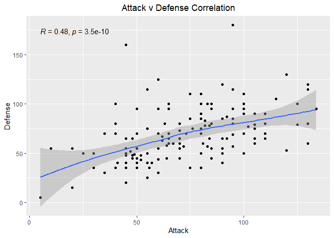

```r
plot6 <- ggplot(kanto, aes(x=attack, y=defense)) + geom_point(stat='identity') + geom_smooth() + stat_cor(mapping = NULL, data = NULL, method = "pearson", alternative = "two.sided") + ggtitle("Attack v Defense Correlation") + xlab("Attack") + ylab("Defense") + theme(plot.title = element_text(hjust = 0.5))
plot6
```

However, in the realm of Pokemon (especially with competitive battling), the most utilized stat is speed (Gotta Catch Em All or Gotta Go Fast?). In any case, we want to see the types with the most speed and see how it corresponds to the results we have already found.

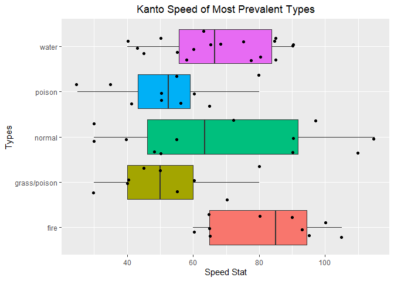

```r
plot7 <- ggplot(kanto_spread, aes(x=type, y=speed, fill=type)) + geom_boxplot(show.legend = FALSE) + geom_jitter(shape=16) + coord_flip() + theme(legend.position = "none") + ggtitle("Kanto Speed of Most Prevalent Types") + xlab("Types") + ylab("Speed Stat") + theme(plot.title = element_text(hjust = 0.5))
plot7
```

Fire seems to be the predominantly powerful type in the original list of 151. WIth pokemon like `Moltres`, `Charizard`, `Flareon` and `Arcanine`, there are a good assortment of options to choose from, as well as teaching powerful moves and using them repeatedly to win battles. However, we know that this generation isn’t the only one present! Let’s take a deeper dive into one of my personal favorites: Generation 3.

### `The Childhood Favorite: Hoenn Region`

We will be following the same structure as the Kanto. There are a completely new set of pokemon to explore, and we want to answer the same question: Which type of pokemon is the best?

```r
hoenn <- pokeAPI("gen", 3)
hoenn <- hoenn %>% mutate(totalstats = hp+attack+defense+special.attack+special.defense+speed)
head(hoenn)
```

```
##        name pokedex_id          type  ability weight hp attack defense special.attack special.defense
## 1   treecko        252         grass overgrow     50 40     45      35             65              55
## 2   grovyle        253         grass overgrow    216 50     65      45             85              65
## 3  sceptile        254         grass overgrow    522 70     85      65            105              85
## 4   torchic        255          fire    blaze     25 45     60      40             70              50
## 5 combusken        256 fire/fighting    blaze    195 60     85      60             85              60
## 6  blaziken        257 fire/fighting    blaze    520 80    120      70            110              70
##   speed catch_rate_pct totalstats
## 1    70             18        310
## 2    95             18        405
## 3   120             18        530
## 4    45             18        310
## 5    55             18        405
## 6    80             18        530
```

Let’s look at the strongest pokemon. As always, legendaries will be a good portion of the list, but let’s see if there are any surprising additions.

[figure not shown]

```r
hoenn_strongest <- top_n(hoenn, n=25, totalstats)

plot8 <- ggplot(hoenn_strongest, aes(x=name, y=totalstats, fill=type)) + geom_bar(stat='identity') + coord_flip() + ggtitle("Strongest Hoenn Pokemon") + xlab("Pokemon Name") + ylab("Total Stats") + theme(plot.title = element_text(hjust = 0.5))
plot8
```

The three starters are present (Blaziken, Sceptile, and Swampert), with Rayquaza being the strongest legendary and pokemon overall. There are a lot higher total stat numbers with this generation than in Kanto, but the craziest find was that Slaking, a very common pokemon, has the second highest total stat count. We’ll dive in further by looking at the `catch_rate`.

[figure not shown]

```r
plot9 <- ggplot(hoenn_strongest, aes(x=name, y=catch_rate_pct, fill=type)) + geom_bar(stat='identity') + coord_flip() + ggtitle("Strongest Hoenn Pokemon Catch Rate") + xlab("Pokemon Name") + ylab("Catch Rate %") + theme(plot.title = element_text(hjust = 0.5))
plot9
```

`Slaking` actually has a relatively decent `catch_rate`, while pokemon like `Milotic`, `Claydol`, and `Wailord` are pretty high in `catch_rate` compared to the rest of the list (makes sense, since a good number of those pokemon are legendaries. Let’s look at the `totalstats` breakdown across all these pokemon.

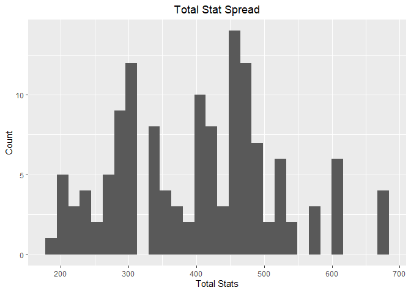

```r
plot10 <- ggplot(hoenn, aes(x=totalstats)) + geom_histogram() + ggtitle("Total Stat Spread") + xlab("Total Stats") + ylab("Count") + theme(plot.title = element_text(hjust = 0.5))
plot10
```

```r
hoenn %>% group_by(type) %>% summarise(avg = round(mean(totalstats)), med = median(totalstats), var = round(var(totalstats)))
```

```
## # A tibble: 48 × 4
##    type            avg   med   var
##    <chr>         <dbl> <dbl> <dbl>
##  1 bug             293   205 15658
##  2 bug/flying      435   454  1201
##  3 bug/ghost       236   236    NA
##  4 bug/ground      266   266    NA
##  5 bug/poison      385   385    NA
##  6 bug/water       269   269    NA
##  7 dark            368   420 17008
##  8 dark/ghost      380   380    NA
##  9 dragon          360   360  7200
## 10 dragon/flying   590   600  9100
## # … with 38 more rows
```

```r
summary(hoenn$totalstats)
```

```
##    Min. 1st Qu.  Median    Mean 3rd Qu.    Max.
##   190.0   303.5   410.0   403.7   475.0   680.0
```

There’s a lower average for `totalstats` in Hoenn compared to Kanto, but a higher median.